# R: Um guia prático

# 5 Gráficos

## 5.1 Histogramas

O `R` também possui um potente arsenal nativo de implementações gráficas. Como no caso das estatísticas básicas, acessamos estas ferramentais via funções. Podemos começar com uma das mais simples: o histograma.

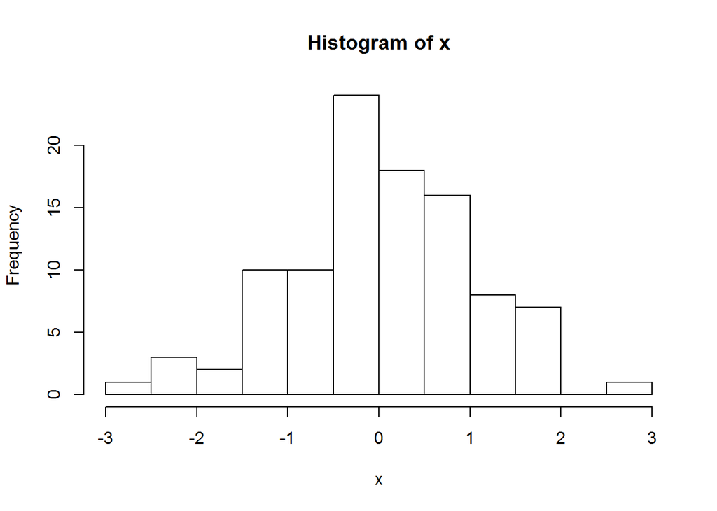

```r
x <- rnorm(100) # cria um vetor
hist(x) # a função hist() cria um histograma
```

A função `hist`, assim como as demais funções gráficas nativas do `R`, possui diversos argumentos opcionais que nos permitem controlar a aparência do gráfico.

Incluímos títulos e mudamos o nome dos eixos com os argumentos `main`, `xlab` e `ylab`, respectivamente.

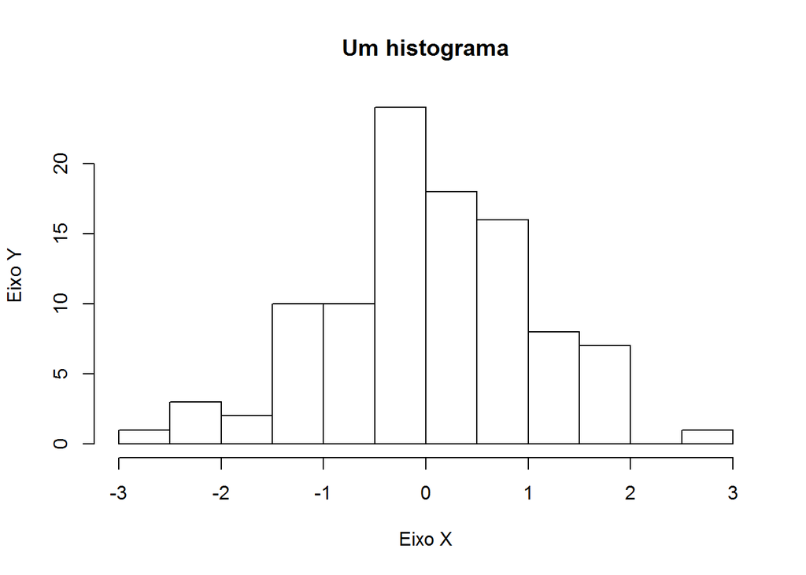

```r
hist(x, main = "Um histograma", xlab = "Eixo X", ylab = "Eixo Y")
```

Mudamos a cor das barras com `col`.

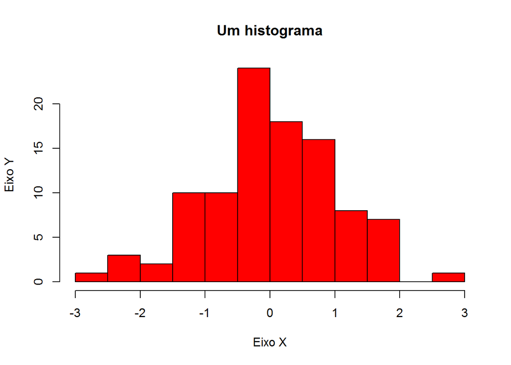

```r
hist(x, main = "Um histograma", xlab = "Eixo X", ylab = "Eixo Y", col = "red")
```

E a espessura das barras (i.e., o número de elementos por barra) com `breaks`.

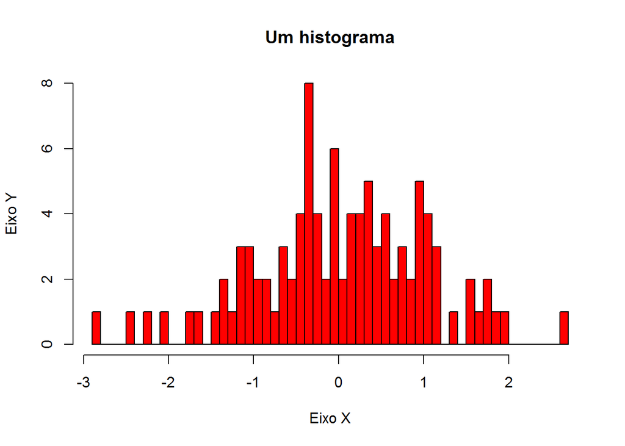

```r
hist(x, main = "Um histograma", xlab = "Eixo X", ylab = "Eixo Y", col = "red", breaks = 50)
```

Para organizar melhor o código, podemos quebrá-lo em linhas - nada mudará na sua execução, mas fica visualmente mais simples de entender o que estamos fazendo.

```r
hist(x, main = "Um histograma",
     xlab = "Eixo X",
     ylab = "Eixo Y",
     col = "red",
     breaks = 50)
```

## 5.2 Scatterplots

Para visualizar relações bivariadas, o gráfico de pontos (*scatterplot*) geralmente é a melhor opção. Criamos ele com a função `plot`.

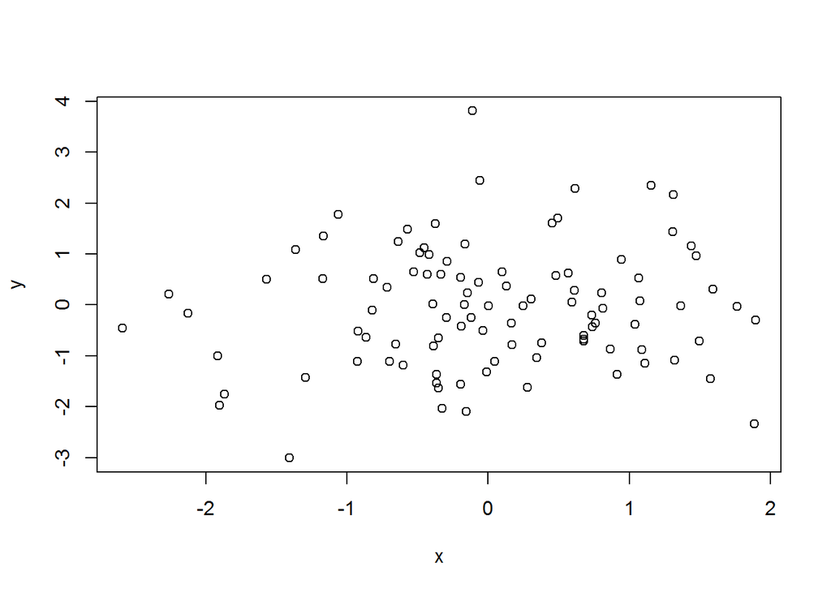

```r
x <- rnorm(100)
y <- rnorm(100)

plot(y ~ x)
```

```r
# plot(x, y) é a mesma coisa
```

Também podemos alterar uma série de elementos do gráfico. Vamos, novamente, mudar títulos e cores.

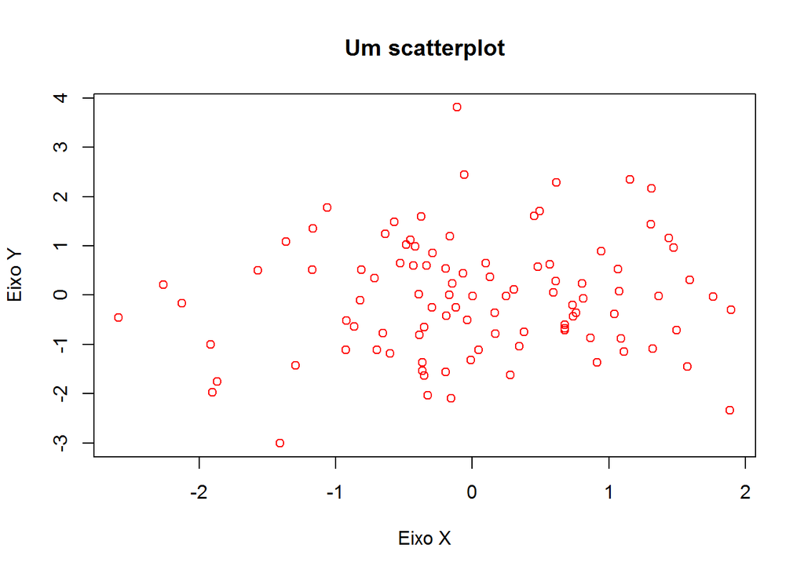

```r
plot(y ~ x, main = "Um scatterplot",
     xlab = "Eixo X",
     ylab = "Eixo Y",
     col = "red")
```

Ainda podemos alterar o formato dos eixos - deixando-os abertos, por exemplo.

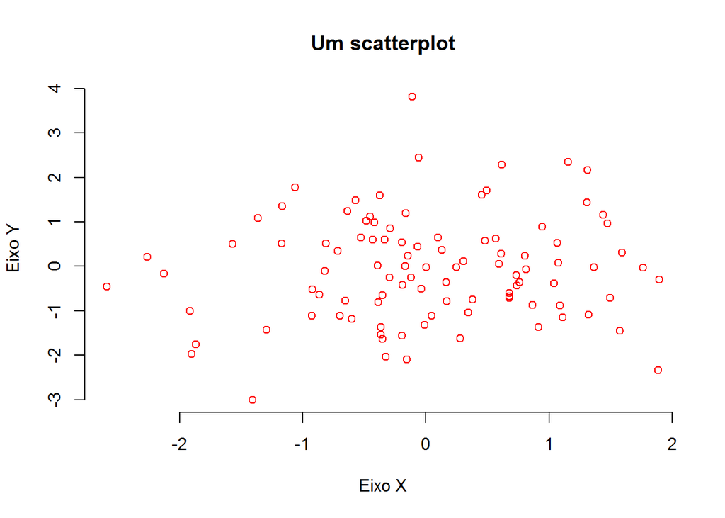

```r
plot(y ~ x, main = "Um scatterplot",
     xlab = "Eixo X",
     ylab = "Eixo Y",
     col = "red",
     bty = "n")
```

E depois mudar o formato dos pontos.

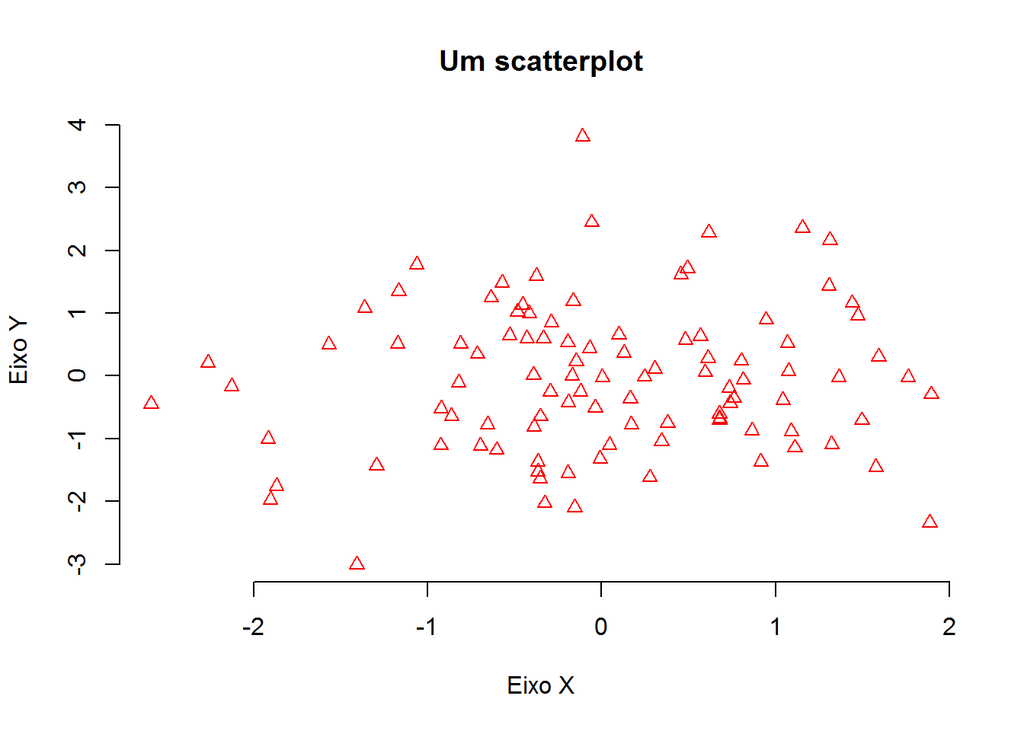

```r
plot(y ~ x, main = "Um scatterplot",
     xlab = "Eixo X",
     ylab = "Eixo Y",
     col = "red",
     bty = "n",
     pch = 2) # pch muda o formato dos pontos
```

Os valores mais comuns de `pch` são ([veja outros aqui](http://www.sthda.com/sthda/RDoc/figure/graphs/r-plot-pch-symbols-points-in-r.png)):

- `0`, para quadrado vazado;
- `1`, para círculo vazado;
- `2`, para triângulo vazado;
- `16`, para círculo pequeno sólido;
- `19`, para círulo grande sólido.

## 5.3 Line plots

Gráficos de linhas, frequentemente usados para plotar séries temporais, também são criados com a função `plot`.

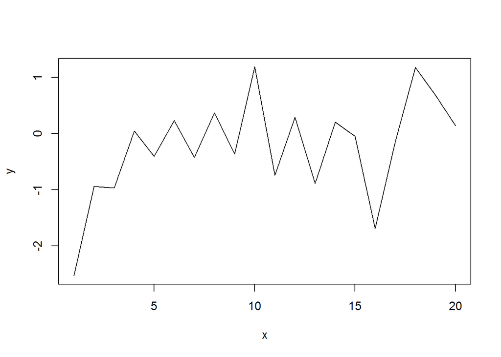

```r
x <- 1:20
y <- rnorm(20)

plot(y ~ x, type = "l")
```

Uma vez que o gráfico esteja criado, podemos adicionar novas linhas a ele com a função `lines`.

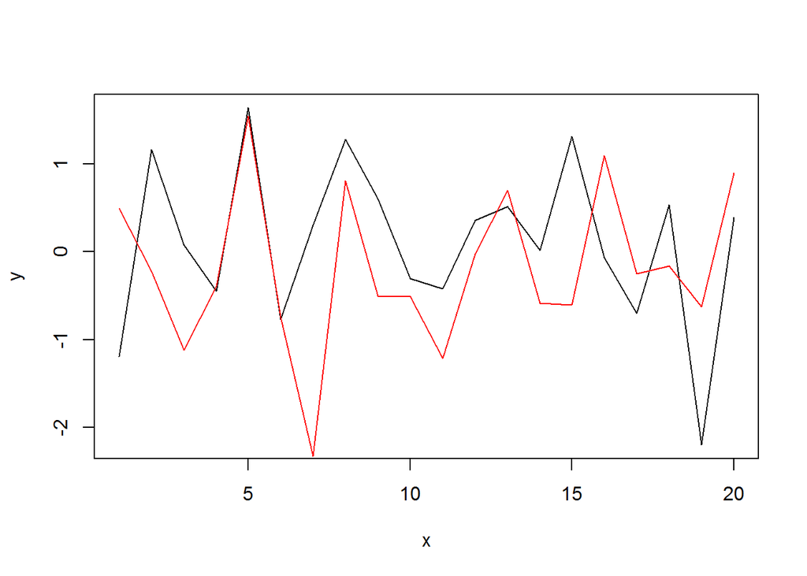

```r
x <- 1:20
y <- rnorm(20)

plot(y ~ x, type = "l")

z <- rnorm(20)
lines(z, col = "red")
```

## 5.4 Pontos e linhas

Para combinar pontos e linhas, basta usar o argumento opcional `type = "b"`.

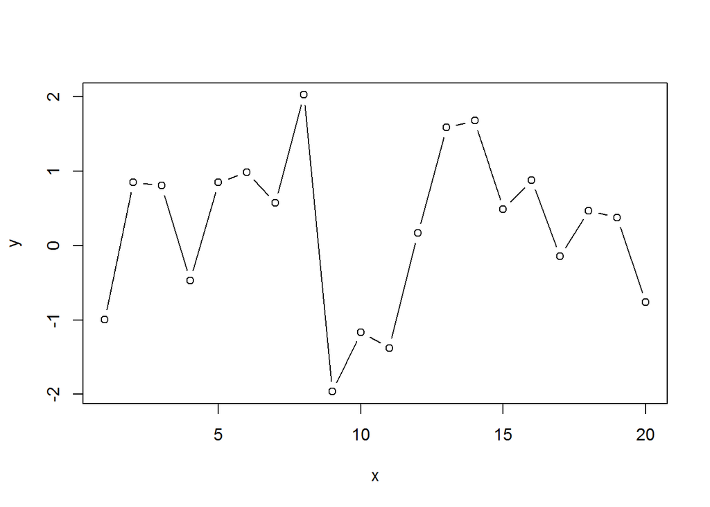

```r
x <- 1:20
y <- rnorm(20)

plot(y ~ x, type = "b")
```

## 5.5 Boxplot

Em algumas situações, precisamos plotar a distribuição de uma variável por grupos: por exemplo, queremos saber a distribuição da nota dos(as) alunos(as) de duas escolas diferentes. Aqui vai um exemplo de como criar um boxplot mais simples, primeiro.

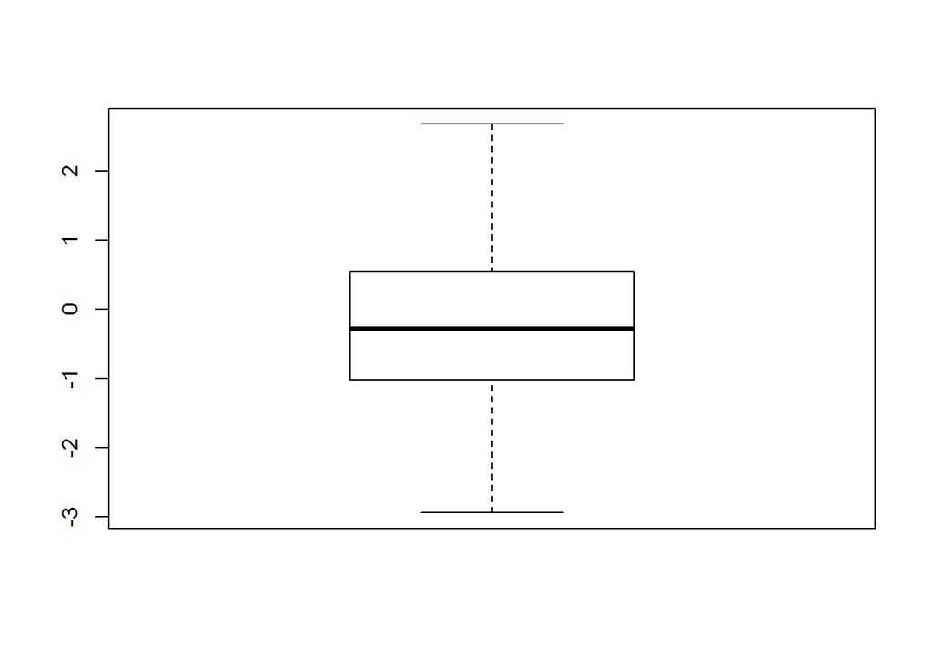

```r
# Boxplot com uma só variável
x <- rnorm(100)
boxplot(x)
```

Agora um exemplo por grupos (precisamos de um vetor que indique quais são estes grupos).

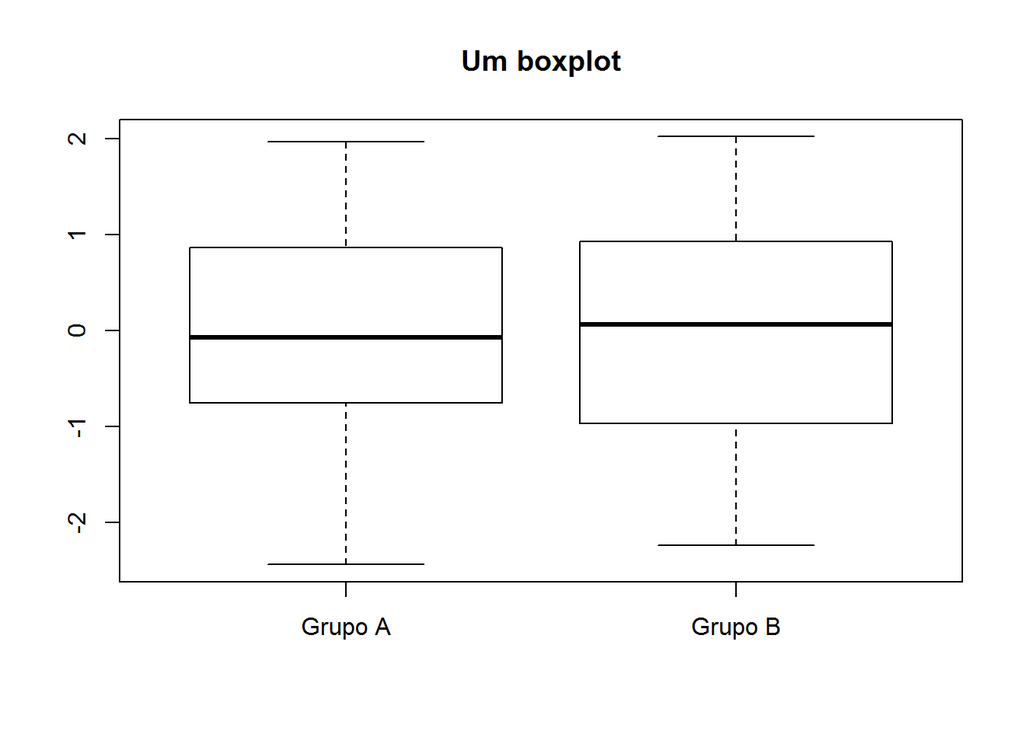

```r
x <- rnorm(100)
grupos <- rep(c("Grupo A", "Grupo B"), each = 50)

boxplot(x ~ grupos, main = "Um boxplot")
```

## 5.6 Gráficos de barras

Por fim, vamos ver como criar gráficos de barras - aqueles gráficos onde cada grupo no eixo X é representado por uma barra indicando o valor dela no eixo Y. Para criar estes gráficos, usamos duas funções combinadas: `table`, para criar uma tabela de frequência, e `plot` ou `barplot`, para plotar o gráfico.

```r
grupoA <- rep("Grupo A", 30)
grupoB <- rep("Grupo B", 20)
grupoC <- rep("GrupoC", 9)
grupos <- c(grupoA, grupoB, grupoC)

grupos <- table(grupos) # table cria uma tabela de frequência

grupos
```

```
## grupos
## Grupo A Grupo B  GrupoC
##      30      20       9
```

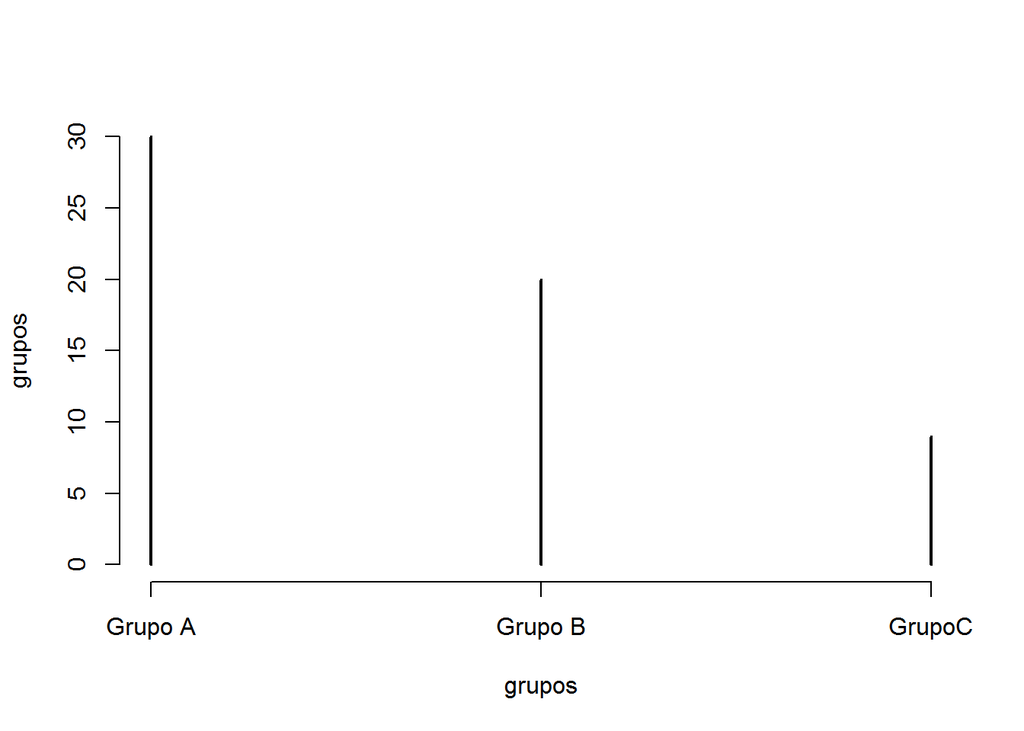

```r
plot(grupos) # cria uma gráfico de barras com plot
```

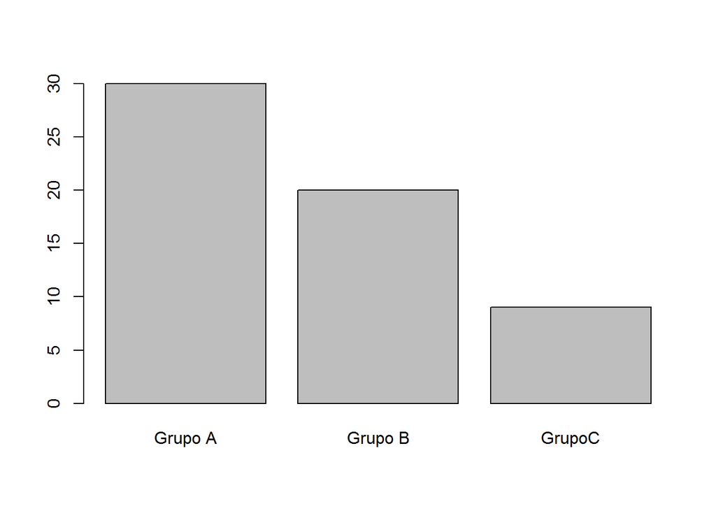

```r
barplot(grupos) # cria um gráfico de barras com barplot
```

## 5.7 Mais gráficos

O `R-base` possui muitas outras opções de gráficos e de funções que, entre outros, nos permitem fazer gráficos como este.

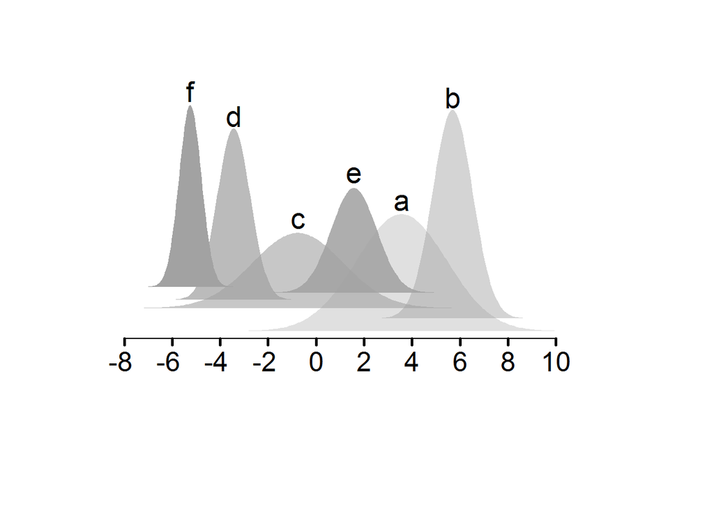

Para saber mais sobre gráficos no `R-base`, um bom guia pode ser visto [aqui](http://shinyapps.org/apps/RGraphCompendium/index.php). Também use a função `help` para obter ajuda sobre argumentos opcionais de cada função.

# 6 Regressão linear

Regressões nos ajudam a entender a relação entre uma variável quantitativa e uma ou mais variáveis explicativas. E o modelo mais usado para realizar este tipo de análise, sem dúvidas, é a [regressão linear](https://pt.wikipedia.org/wiki/Regress%C3%A3o_linear), que modela a relação entre variáveis dependente e independente de forma linear - a reta que melhor se ajusta aos dados. No `R`, podemos estimar regressões como estas com a função `lm`, de *linear model*.

## 6.1 Modelo bivariado

Vamos começar com um exemplo simples: modelar a relação entre dois vetores numéricos.

```r
x <- rnorm(50)
y <- rnorm(50)

modelo <- lm(y ~ x) # estima um modelo linear e salva os resultados no objeto 'modelo'

class(modelo) # a classe do objeto 'modelo' vira 'lm'
```

```
## [1] "lm"
```

```r
summary(modelo) # usamos a função 'summary' para exibir os resultados
```

```
##
## Call:
## lm(formula = y ~ x)
##
## Residuals:
##      Min       1Q   Median       3Q      Max
## -2.40061 -0.66567  0.07957  0.52041  2.99862
##
## Coefficients:
##             Estimate Std. Error t value Pr(>|t|)
## (Intercept)   0.0314     0.1501   0.209    0.835
## x             0.1527     0.1315   1.161    0.252
##
## Residual standard error: 1.061 on 48 degrees of freedom
## Multiple R-squared:  0.0273, Adjusted R-squared:  0.007035
## F-statistic: 1.347 on 1 and 48 DF,  p-value: 0.2515
```

O *output* da função `summary` nos dá um panorama geral dos resultados do modelo. Em ordem:

- `Call`, no topo, indica a fórmula que passamos para o modelo;
- `Residuals` mostra a distribuição dos resíduos;
- `Coefficientes` reporta as estimativas do modelo:
  - `Estimate` reporta os coeficientes;
  - `Std. Error` reporta erros-padrão;
  - `t value` reporta t valores;
  - `Pr(>|t|)` reporta p-valores.
- `Residual standard error`, `Multiple R-squared`, `Adjusted R-squared` e `F-statistic` mostram algumas estatísticas de ajustes do modelo.

Usando a função `plot` [vista anteriormente](http://fmeireles.com/teaching/r_um_guia_pratico.html#52_scatterplots), podemos plotar a reta estimada nos dados originais.

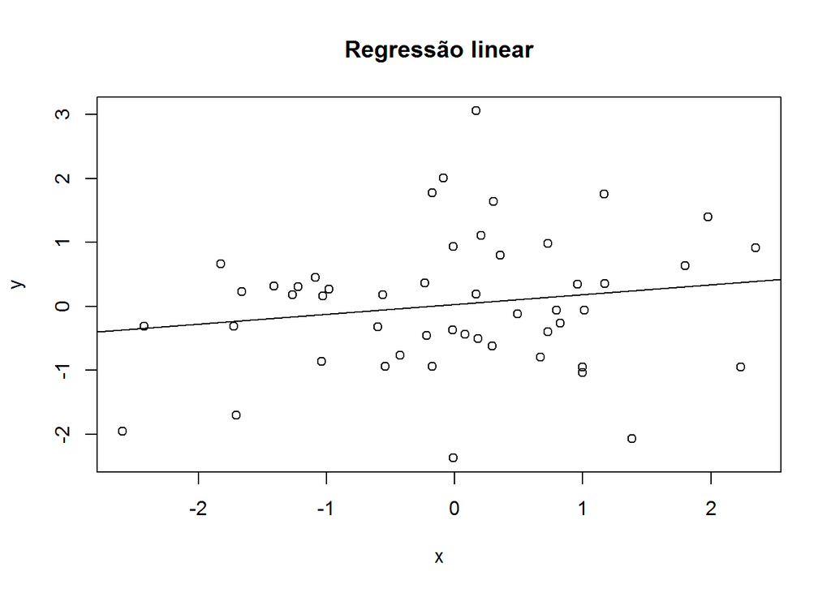

```r
plot(y ~ x, main = "Regressão linear")
abline(modelo) # a função abline toma um objeto 'lm' e plota a reta da regressão
```

Também podemos usar a função `plot` para termos uma noção geral do ajuste de um modelo.

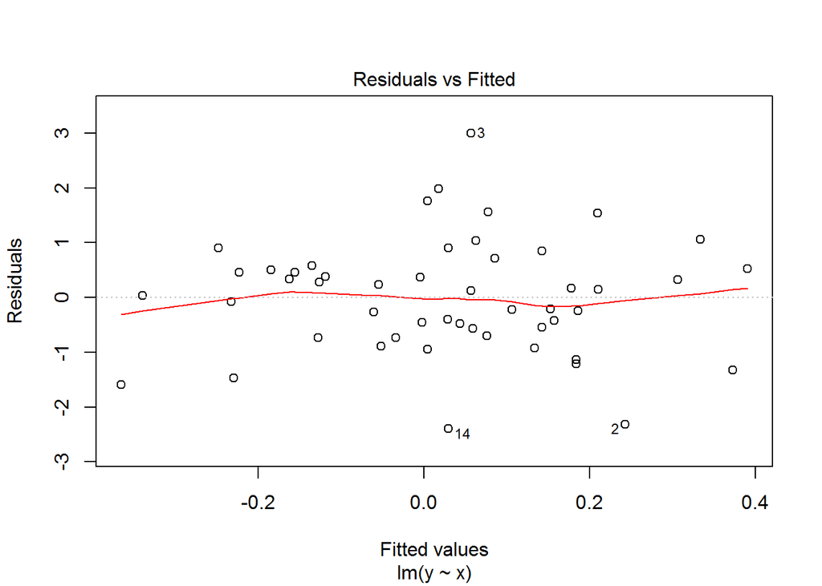

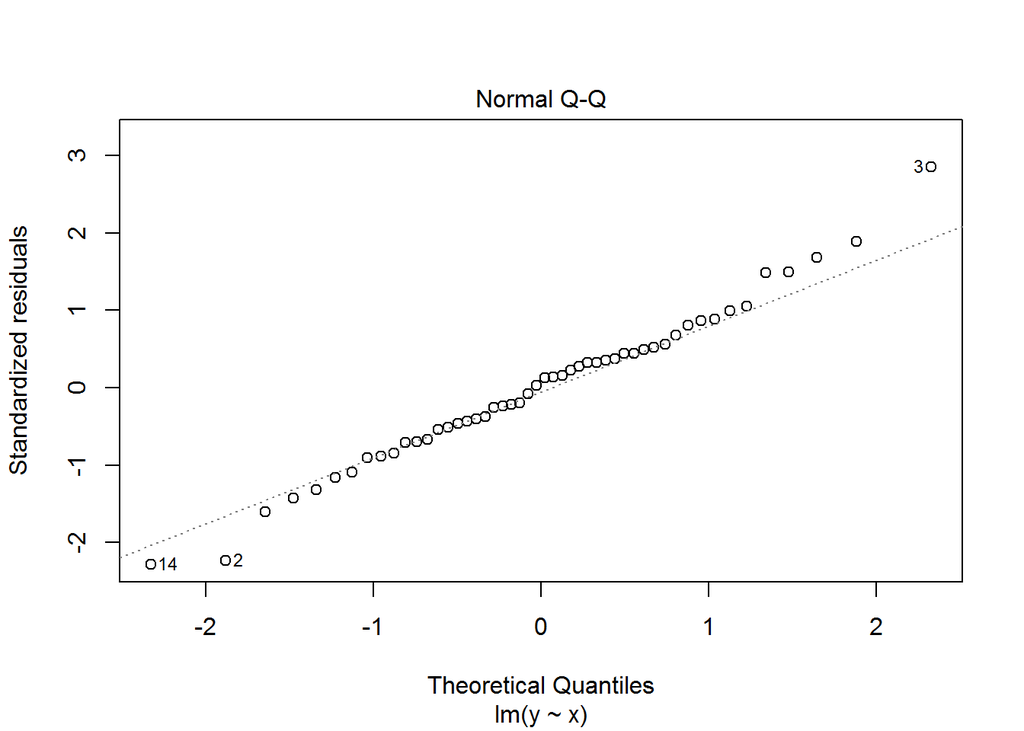

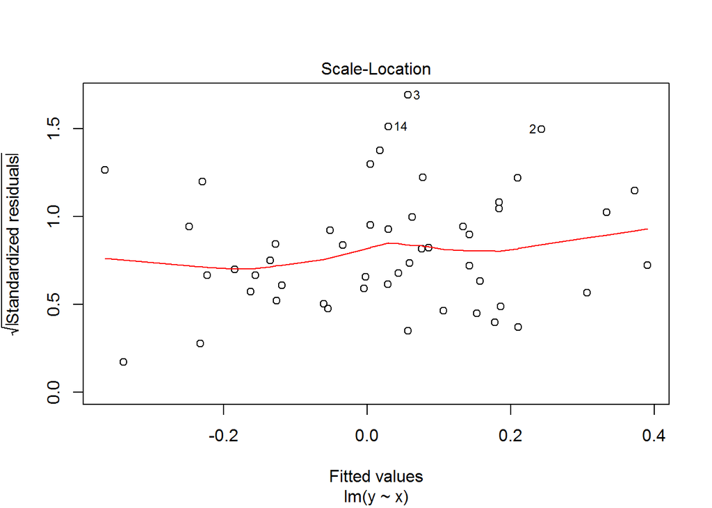

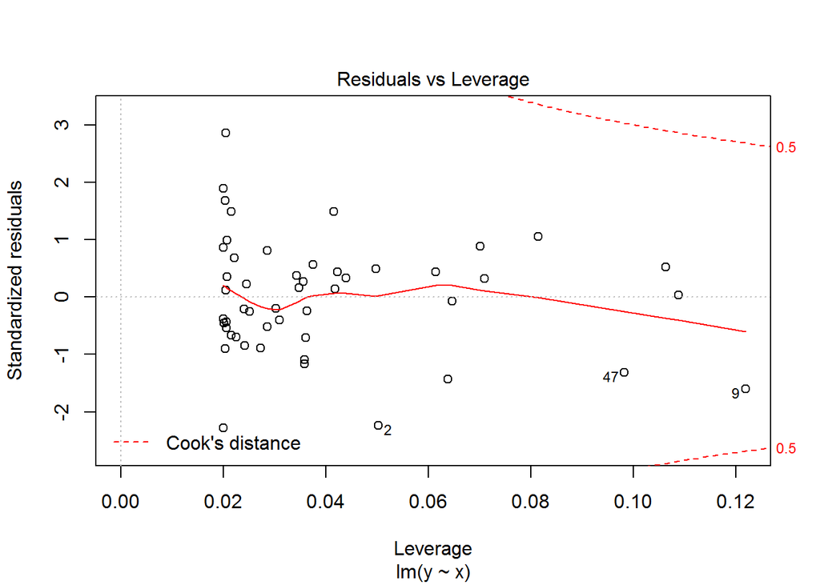

```r
plot(modelo)
```

## 6.2 Modelo multivariado

Modelos lineares podem ter mais de uma variável independente. Usamos a mesma função, `lm`, para fazer isto - a única coisa que modificamos é a fórmula passada ao modelo.

```r
x <- rnorm(50)
z <- rnorm(50)
y <- rnorm(50)

modelo <- lm(y ~ x + z) # adicionamos variável com o operador '+'

summary(modelo)
```

```
##
## Call:
## lm(formula = y ~ x + z)
##
## Residuals:
##      Min       1Q   Median       3Q      Max
## -1.78551 -0.60214 -0.04739  0.60877  1.91859
##
## Coefficients:
##             Estimate Std. Error t value Pr(>|t|)
## (Intercept) -0.15088    0.13230  -1.140    0.260
## x            0.19177    0.12861   1.491    0.143
## z           -0.05275    0.12011  -0.439    0.663
##
## Residual standard error: 0.9347 on 47 degrees of freedom
## Multiple R-squared:  0.0471, Adjusted R-squared:  0.006552
## F-statistic: 1.162 on 2 and 47 DF,  p-value: 0.3218
```

Com mais de duas variáveis independentes no modelo, visualizar a relação entre elas e a variável dependente não é tão simples: o efeito de `x` e `z` são controlados por `z` e `x`, respectivamente. O que podemos fazer é ver o efeito parcial de cada preditor com a função `termplot`. (Na verdade, existem várias outras maneiras de fazer isto, mas a maioria delas pressupõe conhecimentos adicionais de `R`; uma boa referência pode ser vista [aqui](http://www.statmethods.net/stats/regression.html)).

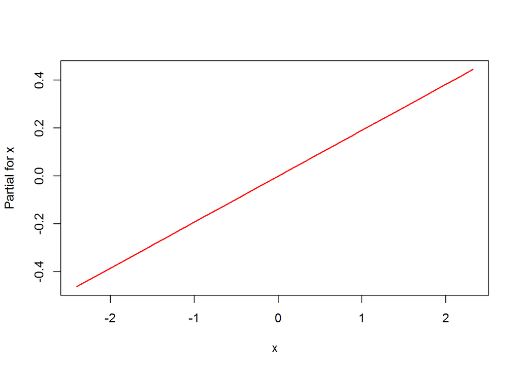

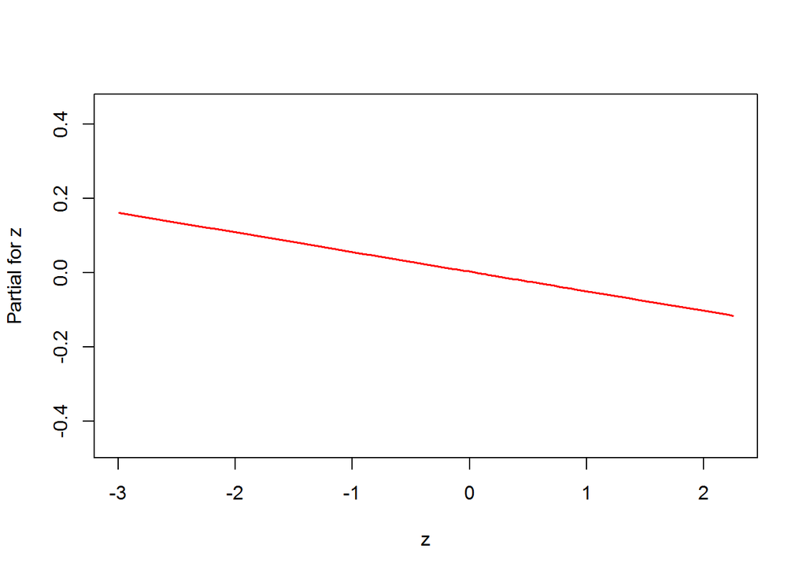

```r
termplot(modelo)
```

## 6.3 Modelo com dummies

Em algumas situações, a relação linear entre duas variáveis pode ser diferente para grupos diferentes. Nestes casos, adicionar uma variável ao modelo indicando estes grupos pode ser uma boa opção.

```r
x <- rnorm(100)
grupo <- rbinom(100, 1, prob = 0.5) # 'rbinom' serve para criar uma variavel com distribuicao binomial

y <- rnorm(100) + grupo # adicionando 'grupo', 'y' sera' afetada por ela

modelo <- lm(y ~ x + grupo)

summary(modelo)
```

```
##
## Call:
## lm(formula = y ~ x + grupo)
##
## Residuals:
##      Min       1Q   Median       3Q      Max
## -2.27228 -0.62717 -0.02431  0.63295  2.37059
##
## Coefficients:
##             Estimate Std. Error t value Pr(>|t|)
## (Intercept)   0.2996     0.1495   2.003  0.04794 *
## x            -0.1147     0.1051  -1.091  0.27810
## grupo         0.6659     0.2121   3.140  0.00224 **
## ---
## Signif. codes:  0 '***' 0.001 '**' 0.01 '*' 0.05 '.' 0.1 ' ' 1
##
## Residual standard error: 1.057 on 97 degrees of freedom
## Multiple R-squared:  0.107,  Adjusted R-squared:  0.08857
## F-statistic:  5.81 on 2 and 97 DF,  p-value: 0.004137
```

O *output* de `summary` já nos indica que a variável `grupo` tem efeito preditivo significativo sobre `y`. Com a função `plot`, podemos ter uma noção visual mais clara disto (usaremos a função `points`, que, assim como `lines`, serve para plotar pontos após um gráfico já ter sido criado).

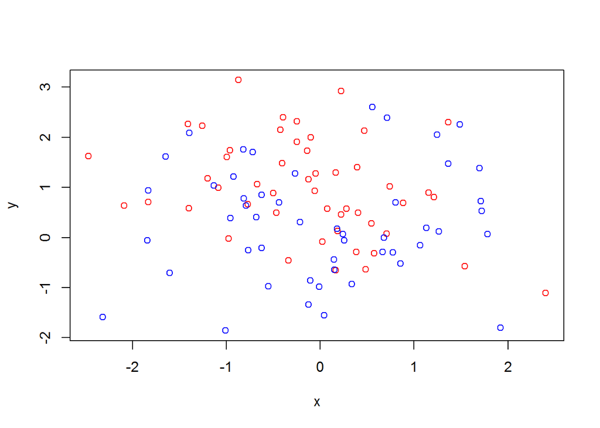

```r
plot(y ~ x, type = "n") # 'type = n' plota apenas os eixos do gráfico
points(y[grupo == 1] ~ x[grupo == 1], col = "red")
points(y[grupo == 0] ~ x[grupo == 0], col = "blue")
```

É possível perceber pelo gráfico que as observações em vermelho (`grupo == 1`) tendem a ter maiores valores no eixo Y. O que vamos fazer, agora, é plotar uma reta de regressão para cada grupo, tomando nosso modelo para fazer isto.

Usaremos a função `fitted` para salvar os valores preditos do modelo e, com isto, plotaremos as retas usando a função `lines` (este exemplo pode parecer complicado, mas envolve apenas coisas que já vimos anteriormente; se tiver dúvidas, tente refazer este exemplo de outras maneiras, até entender).

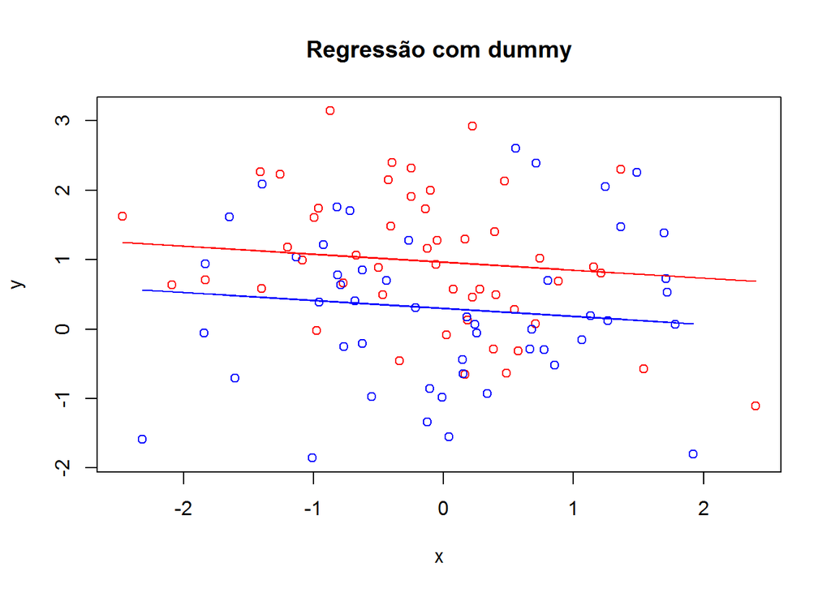

```r
plot(y ~ x, type = "n", main = "Regressão com dummy")

points(y[grupo == 1] ~ x[grupo == 1], col = "red") # p
points(y[grupo == 0] ~ x[grupo == 0], col = "blue")

lines(x[grupo == 1], fitted(modelo)[grupo == 1], col = "red")
lines(x[grupo == 0], fitted(modelo)[grupo == 0], col = "blue")
```

## 6.4 Termos multiplicativos

O exemplo anterior mostra como estimar uma reta para cada grupo num modelo linear, todas com a mesma inclinação. Podemos relaxar isto utilizando termos multiplicativos (`x * grupo`) para fazer com que cada reta se ajuste individualmente ao grupo de dados. Novamente, só modificamos a fórmula passada para a função `lm` para fazer isto.

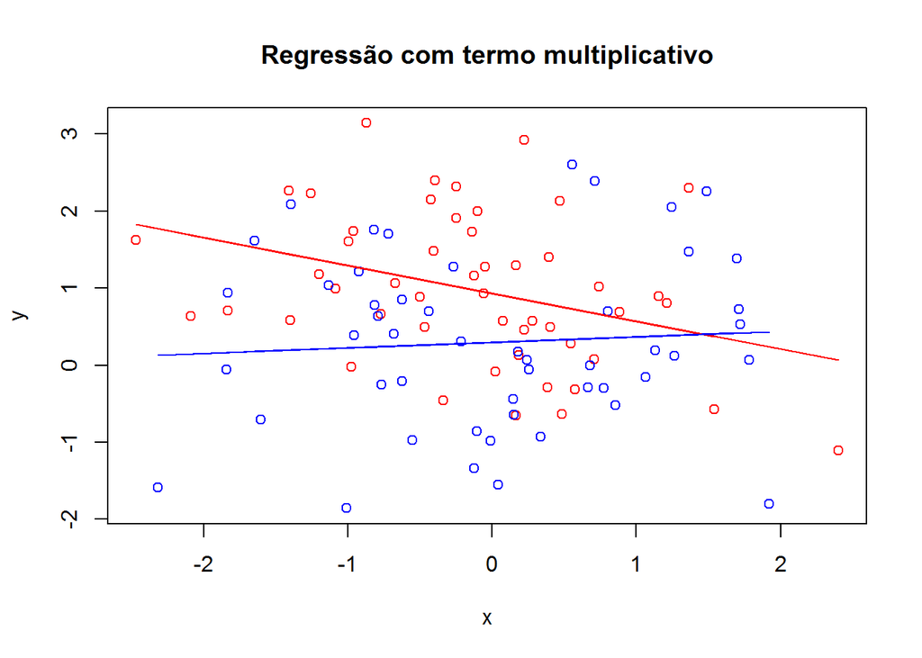

```r
modelo <- lm(y ~ x * grupo) # reestimamos o modelo com o termo multiplicativo

# Criamos novamente o gráfico
plot(y ~ x, type = "n", main = "Regressão com termo multiplicativo")

points(y[grupo == 1] ~ x[grupo == 1], col = "red")
points(y[grupo == 0] ~ x[grupo == 0], col = "blue")

lines(x[grupo == 1], fitted(modelo)[grupo == 1], col = "red")
lines(x[grupo == 0], fitted(modelo)[grupo == 0], col = "blue")
```

## 6.5 Relação quadrática

Relações entre duas variáveis nem sempre são apenas lineares: às vezes, elas assumem algum tipo de curva. Ainda que um modelo linear nem sempre seja a melhor opção para modelar relações como estas, podemos adaptá-lo para dar conta disto. A solução, neste caso, é bem simples: passamos a variável independente ao quadrado para a função `lm`.

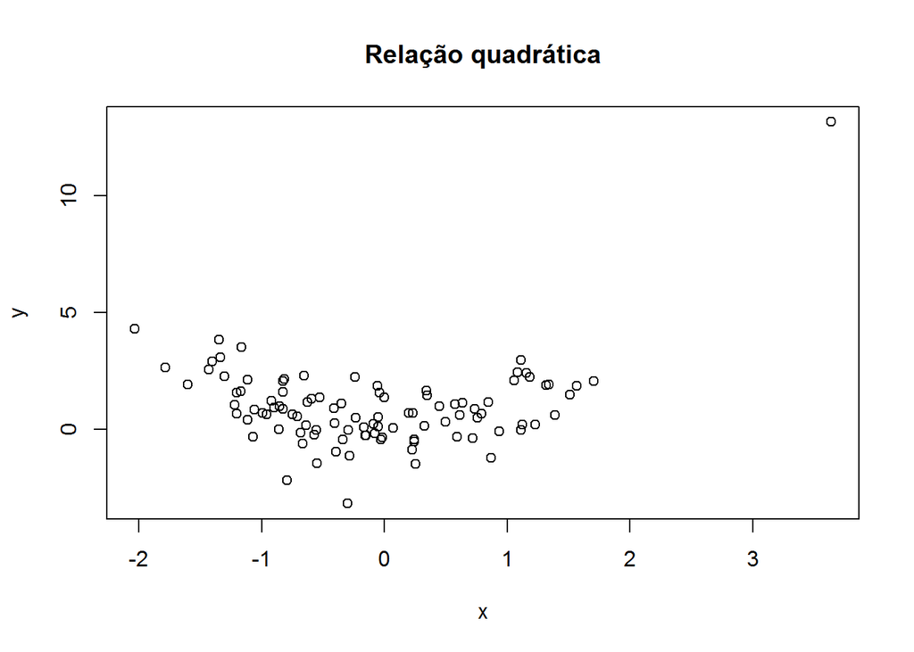

```r
x <- rnorm(100)
x2 <- x^2
y <- x2 + rnorm(100) # adicionando 'x2' a 'y', fazemos com que a relação entre eles seja quadrática

plot(y ~ x, main = "Relação quadrática")
```

Só precisamos passar `x` e `x2` para a fórmula na função `lm` para estimarmos a relação quadrática. Depois, para criarmos o gráfico, precisaremos criar dois novos vetores: 1) `novo_x`, que será um vetor sequencial contendo os valores máximos e mínimos de `x` como referências; e, 2), `pred`, que criaremos usando a função `predict`, que serve para usar um modelo que já estimamos para fazer predições em cima de novos dados (também usaremos a função `list` para passar `x` e `x2` para dentro da função simultaneamente).

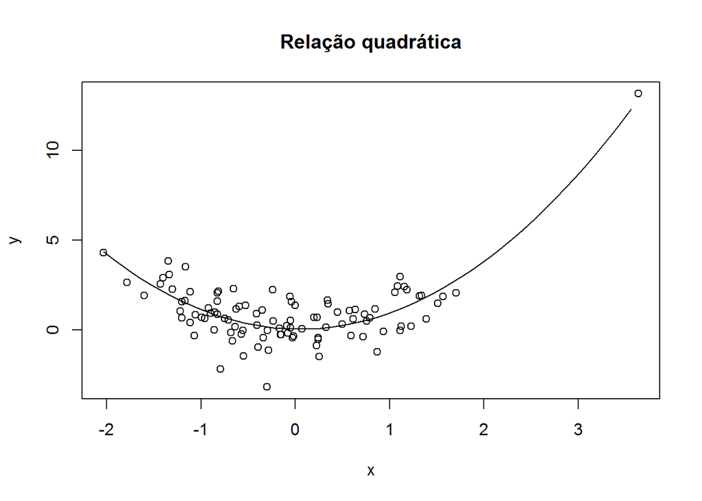

```r
modelo <- lm(y ~ x + x2)

plot(y ~ x, main = "Relação quadrática")

novo_x <- seq(min(x), max(x), by = 0.1)
pred <- predict(modelo, list(x = novo_x, x2 = novo_x^2))

lines(novo_x, pred)
```

O mesmo procedimento também serve para uma relação cúbica.

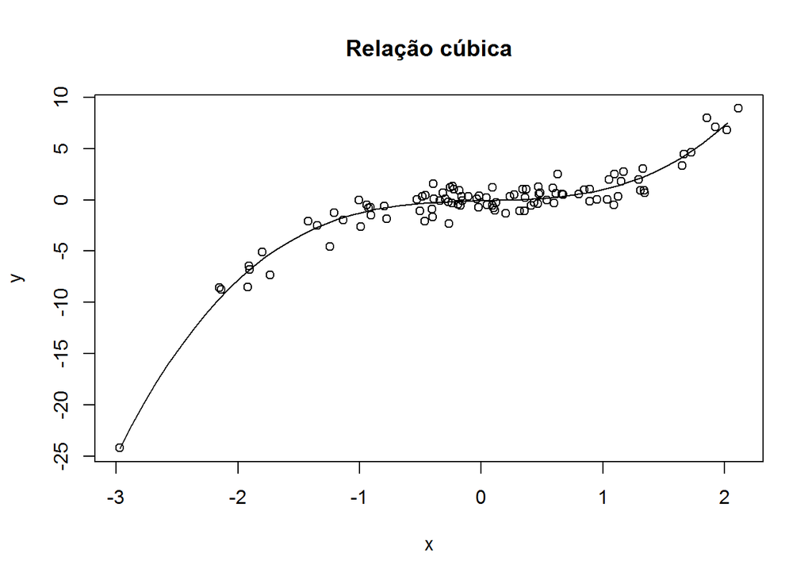

```r
x <- rnorm(100)
x2 <- x^2
x3 <- x^3
y <- x3 + rnorm(100)

modelo <- lm(y ~ x + x2 + x3)

plot(y ~ x, main = "Relação cúbica")

novo_x <- seq(min(x), max(x), by = 0.1)
pred <- predict(modelo, list(x = novo_x, x2 = novo_x^2, x3 = novo_x^3))

lines(novo_x, pred)
```

# 7 Mais

Este é o básico do `R`. Obviamente, mal tocamos na superfície das coisas que ele é capaz de fazer. Não trabalhamos, entre outros, com bancos de dados (`data.frames`), listas, controle de fluxo e nem com códigos desenvolvidos por outras pessoas - o que expande massivamente as possibilidades de uso do `R`. Algumas boas fontes sobre estas e outras coisas incluem:

- Introdutórios
  - A introdução oficial do `R-project` (inglês): [link](https://cran.r-project.org/doc/manuals/r-release/R-intro.html)
  - “Introdução ao R”, escrito por Victor Landeiro: [link](https://cran.r-project.org/doc/contrib/Landeiro-Introducao.pdf)
  - “Referência rápida”: [link](https://cienciapratica.wordpress.com/2015/05/22/r-referencia-rapida/)
  - “Learn R” da CodeSchool: [link](http://tryr.codeschool.com/levels/1/challenges/1)
- Documentação e manuais
  - “Step by Step Guide to Learn Data Science on R” (inglês): [link](https://www.analyticsvidhya.com/learning-paths-data-science-business-analytics-business-intelligence-big-data/learning-path-r-data-science/)
  - “Quick R”: [link](http://www.statmethods.net/)
  - “R Documentation”: [link](https://www.rdocumentation.org/)

## 7.1 Licença

Se precisar citar este material, use:

> MEIRELES, F. (2017). R: Um guia prático. URL: http://fmeireles.com/teaching/r_um_guia_pratico.html.